# Udacity - Intro to Data Analysis Project Submission

This notebook is created to complete the Intro to Data Analysis Project Submission. The dataset I choose for this project is No-show appointments dataset. There will be some few questions from my own and its solutions.

## Import DS Libraries and no-show appointments dataset

The libraries I use here would be pandas, numpy, matplotlib, and seaborn.

```python
import pandas as pd
import numpy as np
import matplotlib.pyplot as plt
import seaborn as sns
%matplotlib inline

df = pd.read_csv("Dataset/noshowappointments-kagglev2-may-2016.csv")
df.head()
```

|  | PatientId | AppointmentID | Gender | ScheduledDay | AppointmentDay | Age | Neighbourhood | Scholarship | Hipertension | Diabetes | Alcoholism | Handcap | SMS_received | No-show |
| --- | --- | --- | --- | --- | --- | --- | --- | --- | --- | --- | --- | --- | --- | --- |
| 0 | 2.987250e+13 | 5642903 | F | 2016-04-29T18:38:08Z | 2016-04-29T00:00:00Z | 62 | JARDIM DA PENHA | 0 | 1 | 0 | 0 | 0 | 0 | No |
| 1 | 5.589978e+14 | 5642503 | M | 2016-04-29T16:08:27Z | 2016-04-29T00:00:00Z | 56 | JARDIM DA PENHA | 0 | 0 | 0 | 0 | 0 | 0 | No |
| 2 | 4.262962e+12 | 5642549 | F | 2016-04-29T16:19:04Z | 2016-04-29T00:00:00Z | 62 | MATA DA PRAIA | 0 | 0 | 0 | 0 | 0 | 0 | No |
| 3 | 8.679512e+11 | 5642828 | F | 2016-04-29T17:29:31Z | 2016-04-29T00:00:00Z | 8 | PONTAL DE CAMBURI | 0 | 0 | 0 | 0 | 0 | 0 | No |
| 4 | 8.841186e+12 | 5642494 | F | 2016-04-29T16:07:23Z | 2016-04-29T00:00:00Z | 56 | JARDIM DA PENHA | 0 | 1 | 1 | 0 | 0 | 0 | No |

## About the Dataset

- PatientID : Registered Patient's ID
- AppointmentID : Registered Appointment ID
- Gender : Patient's gender type
- ScheduledDay : The day where the patient came to make an appointment
- AppointmentDay : The day when the patient made the appointment for
- Age : Age of the patient
- Neighbourhood : Where the appointment takes place
- Scholarship : True or False, whether the patient received a scholarship from Bolsa Familia or not
- Hipertension : True or False, whether the patient have hypertension or not
- Diabetes : True or False, whether the patient have diabetes or not
- Alcoholism : True or False, whether the patient drinks alcohol or not
- Handcap : True or False, whether the patient handicapped or not
- SMS_received : True or False, whether 1 or more messages sent to the patient or not
- No-show : True or False, whether the patient show up or not  
  These column details are based on my interpretation from the Kaggle website, so there could be wrong details. Here is the [link](https://www.kaggle.com/joniarroba/noshowappointments) to the dataset resource

## Investigate Dataset Structure

- data type consistency
- null values
- duplicate values
- inconsistent value

### Data type consistency

```python
df.info()
```

```
<class 'pandas.core.frame.DataFrame'>
RangeIndex: 110527 entries, 0 to 110526
Data columns (total 14 columns):
 #   Column          Non-Null Count   Dtype
---  ------          --------------   -----
 0   PatientId       110527 non-null  float64
 1   AppointmentID   110527 non-null  int64
 2   Gender          110527 non-null  object
 3   ScheduledDay    110527 non-null  object
 4   AppointmentDay  110527 non-null  object
 5   Age             110527 non-null  int64
 6   Neighbourhood   110527 non-null  object
 7   Scholarship     110527 non-null  int64
 8   Hipertension    110527 non-null  int64
 9   Diabetes        110527 non-null  int64
 10  Alcoholism      110527 non-null  int64
 11  Handcap         110527 non-null  int64
 12  SMS_received    110527 non-null  int64
 13  No-show         110527 non-null  object
dtypes: float64(1), int64(8), object(5)
memory usage: 11.8+ MB
```

There are no null values so we leave the null values problem. But some data types are wrong. My fix would be :

- String : PatientID, AppointmentID
- Boolean : Scholarship, Hipertension, Diabetes, Alcoholism, Handcap, SMS_received
- Category : No-show, Gender
- datetime : ScheduledDay, AppointmentDay

```python
list_object = ['PatientId', 'AppointmentID'] #variables to be converted into string
list_bool = ['Scholarship', 'Hipertension', 'Diabetes', 'Alcoholism', 'Handcap', 'SMS_received'] #variables to be converted into bool
list_category = ['Gender','No-show'] #variables to be converted into category
list_datetime = ['ScheduledDay', 'AppointmentDay'] #variables to be converted into datetime
df[list_object] = df[list_object].astype('object') #converting into string
df[list_bool] = df[list_bool].astype('bool') #converting into boolean
df[list_category] = df[list_category].astype('category') #converting into category
df[list_datetime] = df[list_datetime].astype('datetime64') #converting into datetime
```

```python
df.info()
```

```
<class 'pandas.core.frame.DataFrame'>
RangeIndex: 110527 entries, 0 to 110526
Data columns (total 14 columns):
 #   Column          Non-Null Count   Dtype
---  ------          --------------   -----
 0   PatientId       110527 non-null  object
 1   AppointmentID   110527 non-null  object
 2   Gender          110527 non-null  category
 3   ScheduledDay    110527 non-null  datetime64[ns]
 4   AppointmentDay  110527 non-null  datetime64[ns]
 5   Age             110527 non-null  int64
 6   Neighbourhood   110527 non-null  object
 7   Scholarship     110527 non-null  bool
 8   Hipertension    110527 non-null  bool
 9   Diabetes        110527 non-null  bool
 10  Alcoholism      110527 non-null  bool
 11  Handcap         110527 non-null  bool
 12  SMS_received    110527 non-null  bool
 13  No-show         110527 non-null  category
dtypes: bool(6), category(2), datetime64[ns](2), int64(1), object(3)
memory usage: 5.9+ MB
```

### Duplicate values

Finding duplicate values if available

```python
df[df.duplicated()] #find duplicates
```

|  | PatientId | AppointmentID | Gender | ScheduledDay | AppointmentDay | Age | Neighbourhood | Scholarship | Hipertension | Diabetes | Alcoholism | Handcap | SMS_received | No-show |
| --- | --- | --- | --- | --- | --- | --- | --- | --- | --- | --- | --- | --- | --- | --- |

It seems there is no duplicate row from this dataset. We can go to the next step.

### Inconsistent value

Finding inconsistent value such as outliers or not logical values

```python
df.describe() #find summary statistics
```

|  | Age |
| --- | --- |
| count | 110527.000000 |
| mean | 37.088874 |
| std | 23.110205 |
| min | -1.000000 |
| 25% | 18.000000 |
| 50% | 37.000000 |
| 75% | 55.000000 |
| max | 115.000000 |

The minimum of Age variable is -1, which is impossible for a human age. It looks it's actually null values. Delete those rows would make the dataset cleaner

```python
df = df[df['Age']>=0] #eliminate inconsistent or null value
df.info()
```

```
<class 'pandas.core.frame.DataFrame'>
Int64Index: 110526 entries, 0 to 110526
Data columns (total 14 columns):
 #   Column          Non-Null Count   Dtype
---  ------          --------------   -----
 0   PatientId       110526 non-null  object
 1   AppointmentID   110526 non-null  object
 2   Gender          110526 non-null  category
 3   ScheduledDay    110526 non-null  datetime64[ns]
 4   AppointmentDay  110526 non-null  datetime64[ns]
 5   Age             110526 non-null  int64
 6   Neighbourhood   110526 non-null  object
 7   Scholarship     110526 non-null  bool
 8   Hipertension    110526 non-null  bool
 9   Diabetes        110526 non-null  bool
 10  Alcoholism      110526 non-null  bool
 11  Handcap         110526 non-null  bool
 12  SMS_received    110526 non-null  bool
 13  No-show         110526 non-null  category
dtypes: bool(6), category(2), datetime64[ns](2), int64(1), object(3)
memory usage: 6.7+ MB
```

It looks like there is only one row with -1 age. At least the dataset now is slightly cleaner.

## Exploratory Data Analysis

I found some new insights based on few questions. The questions are :

- Visualize the scheduled day and appointment day based on No-show column to see if there is any seasonal effect
- Find the patient's gender distribution to see if there is something interesting
- Do older people tends to show up on appointment day?
- Which column tends to be the most important variable to No-show column?

### Visualize the scheduled day and appointment day based on No-show column to find if there is any seasonal effect

There would be two visualizations, the scheduled day by no-show column and appointment day by no-show column. The time window would be between a month starts from the earliest.

#### Scheduled Day & No-show

```python
# plotting function
def plot_timeseries(cur_df,column):
    plt.figure(figsize=(10,5)) #create matplotlib figure size
    cur_df.groupby([cur_df[column].dt.year, cur_df[column].dt.month])['No-show'].value_counts().unstack()['No'].plot() #plot time series with 'No' value
    cur_df.groupby([cur_df[column].dt.year, cur_df[column].dt.month])['No-show'].value_counts().unstack()['Yes'].plot() #plot time series with 'Yes' value
    # On the 2nd and 3rd line, those can be written with one line instead. But I can't change the figure size
    # and the x label seems cramped
    plt.xlabel('Year,Month')
    plt.ylabel('Amount of shown')
    plt.legend()
    plt.title('Monthly Not Shown on Scheduled Day');
```

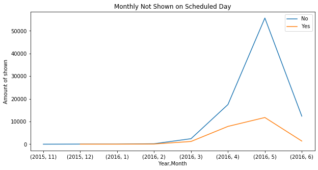

```python
plot_timeseries(df,'ScheduledDay')
```

#### Appointment Day & No-show

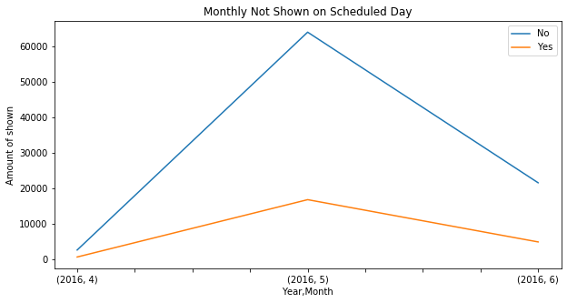

```python
plot_timeseries(df,'AppointmentDay')
```

About the No-show variable, it seems most of the people show up for the appointment day. Let's find the proportion between yes and no value

```python
df['No-show'].value_counts() / len(df) #find proportion on 'No-show' variable
```

```
No     0.798066
Yes    0.201934
Name: No-show, dtype: float64
```

Almost 80% of the patients really show up for the appointment day.

### Find the patient's gender distribution to see if there is something interesting

```python
def hist_plot(cur_df,column):
    plt.figure(figsize=(5,5))
    plt.hist(cur_df[column])
    plt.xlabel('Gender')
    plt.ylabel('Amount of patients')
    plt.title("Patient's age distribution")
```

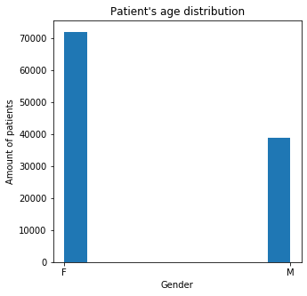

```python
hist_plot(df,'Gender')
```

Most of the patients came to make an appointment are female. Currently I don't really know what causes this. It's worth to investigate more why did this happened. Unfortunately, this dataset doesn't tell us what kind of disease the patient received and the population in that specific area. It could be most of the disease attacks female or that most of the people here are female (this could be analyzed further with additional dataset though).

### Do older people tends to show up on appointment day?

Let's visualize the age and No-show variable using Boxplot

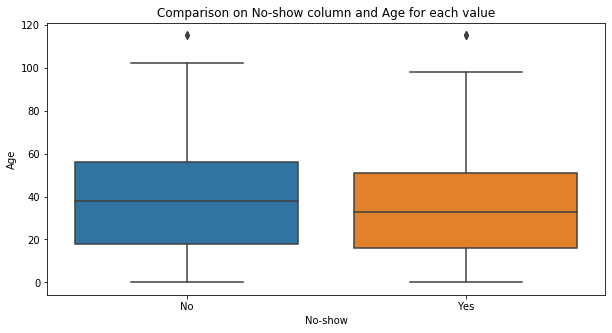

```python
plt.figure(figsize=(10,5))
sns.boxplot(x='No-show',y='Age',data=df) #create boxplot
plt.title('Comparison on No-show column and Age for each value');
```

I don't think there is much of difference between Yes or no values. But the upper quartile, median, and lower quartile from those who shows up seems higher than those who doesn't show up. It means that most older people tends to show up on appointment day. Still, it doesn't mean every younger people would not show on the appointment day.

I'd like to investigate more about how the proportion is between child, teen, adult, and an elder that shows up. To do this, I have to make different age ranges to make it easier to read. Here, I'm assuming that children are between 0 to 13, teen between 13 and 18, adult between 18 and 50, and elder above than 50. And then, I can group by the age range, find the mean, and get the final result from No-show variable

```python
# Make different age range
df['Age_range'] = pd.cut(df['Age'], bins=[0,13,18,50,df['Age'].max()], labels=['child','teen','adult','elder'])

# Find proportion to No-show column
def find_proportion(cur_df,column):
    # copy current dataframe
    temp_df = cur_df.copy()

    # change No-show variable values into 0 for 'No' and 1 for 'Yes'
    temp_df['No-show'] = temp_df['No-show'].apply(lambda x: 0 if x=="No" else 1).astype('int')

    # group by column, and then get the mean with no-show to see the proportion
    print(temp_df.groupby(column).mean()['No-show'])
```

```python
find_proportion(df,'Age_range')
```

```
Age_range
child    0.213495
teen     0.258213
adult    0.221576
elder    0.161675
Name: No-show, dtype: float64
```

### Which column tends to be the most important variable to No-show column?

There are many methods to find the most important variables. I use two methods to find Feature Importance, which are Correlation and Random Forest.  
For this problem, I need to delete 'AppointmentID' and 'PatientId' variable because it is not needed. It just tells us that the id is unique and there would be nothing more to tell. This need to be done too for 'ScheduledDay', 'AppointmentDay' as they only tells us the day they made an appointment. Last variable to be dropped is 'Neighbourhood' variable. Actually I could use this variable to convert it into one hot encoder, but the unique values are way too many. Therefore, using LabelEncoder on that variable would make it a high number of value. This could affect the result of Random Forest model.

Now let's drop the variables that are not needed

```python
importance = df.drop(['Neighbourhood','PatientId','AppointmentID','ScheduledDay','AppointmentDay','Age_range'],axis=1) #drop columns
```

Also in this problem, we need to convert every variables into number values. Other than boolean, Scikit's Label Encoder would be good to convert categorical data into numbers

```python
from sklearn.preprocessing import LabelEncoder
to_number_var = ['Gender','No-show'] #variables to be converted
le = LabelEncoder() #create LabelEncoder object
for column in to_number_var: # Convert each variables as needed
    importance[column] = le.fit_transform(importance[column]) #converting variables
```

Not to forget the 'Age' variable should be rescaled so it doesn't heavily affect the Random Forest model

```python
from sklearn.preprocessing import MinMaxScaler
importance_columns = importance.columns.values #get column names
scaler = MinMaxScaler() #create scaler object
importance = pd.DataFrame(scaler.fit_transform(importance)) #rescale values into scale of 0 to 1
importance.columns = importance_columns #assign current importance column names
```

```python
importance.head()
```

|  | Gender | Age | Scholarship | Hipertension | Diabetes | Alcoholism | Handcap | SMS_received | No-show |
| --- | --- | --- | --- | --- | --- | --- | --- | --- | --- |
| 0 | 0.0 | 0.539130 | 0.0 | 1.0 | 0.0 | 0.0 | 0.0 | 0.0 | 0.0 |
| 1 | 1.0 | 0.486957 | 0.0 | 0.0 | 0.0 | 0.0 | 0.0 | 0.0 | 0.0 |
| 2 | 0.0 | 0.539130 | 0.0 | 0.0 | 0.0 | 0.0 | 0.0 | 0.0 | 0.0 |
| 3 | 0.0 | 0.069565 | 0.0 | 0.0 | 0.0 | 0.0 | 0.0 | 0.0 | 0.0 |
| 4 | 0.0 | 0.486957 | 0.0 | 1.0 | 1.0 | 0.0 | 0.0 | 0.0 | 0.0 |

Now we're ready to find the feature importance

#### Correlation method

I only need to compare 'No-show' variable with the others. I can ignore the comparison between the other variables

```python
importance.corr()['No-show'].sort_values(ascending=False) #get correlation by 'No-show' variable
```

```
No-show         1.000000
SMS_received    0.126428
Scholarship     0.029134
Alcoholism     -0.000197
Gender         -0.004122
Handcap        -0.007281
Diabetes       -0.015181
Hipertension   -0.035704
Age            -0.060327
Name: No-show, dtype: float64
```

#### Random Forest Method

This is different from the correlation method. I have to train the Random Forest model first, then I can find its feature importance.

```python
from sklearn.ensemble import RandomForestClassifier
clf = RandomForestClassifier() #create random forest model
clf.fit(importance.drop('No-show',axis=1), importance[['No-show']]) #train the model
```

```
RandomForestClassifier(bootstrap=True, ccp_alpha=0.0, class_weight=None,
                       criterion='gini', max_depth=None, max_features='auto',
                       max_leaf_nodes=None, max_samples=None,
                       min_impurity_decrease=0.0, min_impurity_split=None,
                       min_samples_leaf=1, min_samples_split=2,
                       min_weight_fraction_leaf=0.0, n_estimators=100,
                       n_jobs=None, oob_score=False, random_state=None,
                       verbose=0, warm_start=False)
```

Now we can get the most important features

```python
feat_labels = importance.columns #get column names to identify importances
for feature in zip(feat_labels, clf.feature_importances_): #get the variable name and its importances
    print(feature)
```

```
('Gender', 0.018170807076439054)
('Age', 0.6850483234941273)
('Scholarship', 0.017964092048336343)
('Hipertension', 0.019579779654318584)
('Diabetes', 0.012602648823683534)
('Alcoholism', 0.015145319369276189)
('Handcap', 0.010567917813254151)
('SMS_received', 0.22092111172056483)
```

The result is different from what correlation method did. The score of 'Age' variable seems much higher with 0.686 score, meaning this variable is the most important compared to the other variables. According to this model, the above Boxplot visualization seems to be correct where older people tends to show up for the appointment.

## Conclusion

Hopefully this notebook would give you a meaningful insight about No-show appointments dataset. Thank you to Udacity and mentors for the lesson they gave to me about Data Analysis!

## References

Here are the blogs I read to complete this project :

1. [Geeksforgeeks](https://www.geeksforgeeks.org/ml-label-encoding-of-datasets-in-python/)
2. [Towards Data Science](https://towardsdatascience.com/feature-selection-techniques-in-machine-learning-with-python-f24e7da3f36e)
3. [Chrisalbon](https://chrisalbon.com/machine_learning/trees_and_forests/feature_selection_using_random_forest/)